# Pessoas com deficiência no mercado de trabalho formal - 2020

Nabil Murtadha e Laura Gontijo - Instituto Ensino e Pesquisa APAE Brasil

# 1 RAIS 2020

## 1.1 Sobre a RAIS

A Relação Anual de Informações Sociais (RAIS) é um **Registro Administrativo** de **periodicidade anual** e apresenta todos os **estabelecimentos formais** e **vínculos celetistas e estatutários** no Brasil.

Portanto, a RAIS contém registros de todo o emprego formal ocorrido no ano de referência. O formulário da RAIS possui duas variáveis relacionadas às pessoas com deficiência, são elas:

- Indicador se o empregado/servidor de portador de deficiência habilitado ou beneficiário reabilitado (PORT DEFIC)
- Tipo de deficiência/Beneficiário habilitado (TP DEFIC)

  A RAIS de 2020 registrou um estoque de **46.236.176** de empregos formais, desse número, **623.827** foram profissionais com deficiência, destes, **495.479** estavam ativos até 31 de dezembro de 2020, enquanto, **128.348** foram desligados no mesmo período. Pode-se concluir que **20,57%** de pessoas com deficiência foram desligadas em 2020.

# 2 Características das pessoas com deficiência no mercado de trabalho formal de 2020

## 2.1 Sexo

A tabela sugere que a condição pessoa com deficiência somada ao gênero pode dificultar o ingresso da pessoa no mundo do trabalho. Enquanto entre as mulheres sem deficiência o percentual daquelas inseridas no mundo do trabalho é de 43,59% em relação ao total da população, entre aquelas que possuem alguma deficiência esse percentual cai para 36,53%.

**Sexo**

| Sexo | Qtd Absoluta | Porcentagem |
| --- | --- | --- |
| Masculino | 314.469 | 63.47% |
| Feminino | 181.010 | 36.53% |

*Fonte: RAIS 2020*

## 2.2 Grau de instrução

Com relação ao grau de instrução, dentre as pessoas com deficiência no mercado de trabalho formal de 2020, a maioria possui **Ensino Médio Completo** seguidos por aqueles que possuem **Ensino Superior Completo**. São proporções próximas ao observado na população de modo geral.

**Escolaridade**

| Grau de instrução | Qtd Absoluta | Porcentagem |
| --- | --- | --- |
| Medio Completo | 241.109 | 48.66% |
| Superior Completo | 89.011 | 17.96% |
| Fundamental Incompleto | 65.268 | 13.17% |
| Fundamental Completo | 41.566 | 8.39% |
| Medio Incompleto | 33.029 | 6.67% |
| Superior Incompleto | 20.760 | 4.19% |
| Analfabeto | 3.900 | 0.79% |

*Fonte: RAIS 2020*

## 2.3 Raça/cor

Na base total de 2020, **37,5% são de raça/cor branca** e **27,6% pardos**. Já, dentre as pessoas com deficiência, **metade são da raça/cor branca**. São proporções próximas ao observado na população de modo geral.

**Raça/Cor**

| Raça/Cor | Qtd Absoluta | Porcentagem |
| --- | --- | --- |
| Branca | 226.296 | 52.52% |
| Parda | 168.681 | 39.15% |
| Preta | 31.555 | 7.32% |
| Amarela | 3.460 | 0.80% |
| Indígena | 895 | 0.21% |

*Fonte: RAIS 2020*

## 2.4 Tipo de deficiência

Dentre as pessoas que possuem deficiência o tipo de maior incidência, dentre os que estão ativos no mercado de trabalho, é a física. Comparado com o Censo de 2010 (IBGE), o último divulgado, esse percentual acompanha os percentuais da população com deficiência.

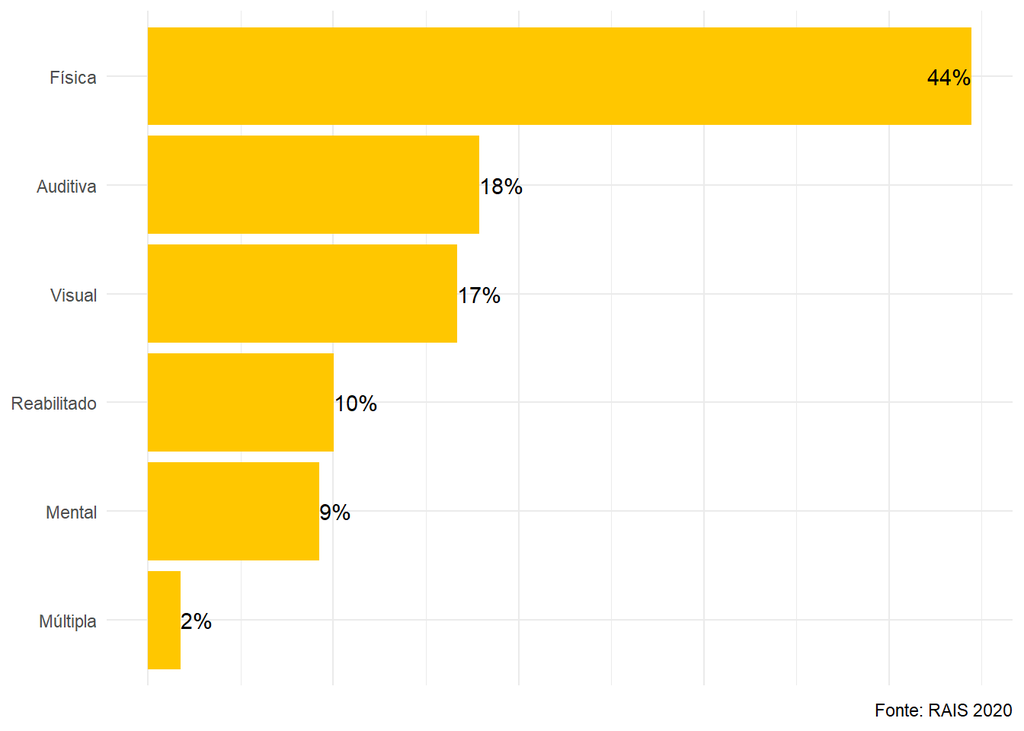

## 2.5 Idade por tipo de deficiência

No ano de 2020 a faixa etária de maior proporção é a de **30 a 39 anos**, com 30% dos estoques do ano de referência. No gráfico abaixo, o **reabilitado** possui uma proporção maior nas faixas de idade mais elevadas.

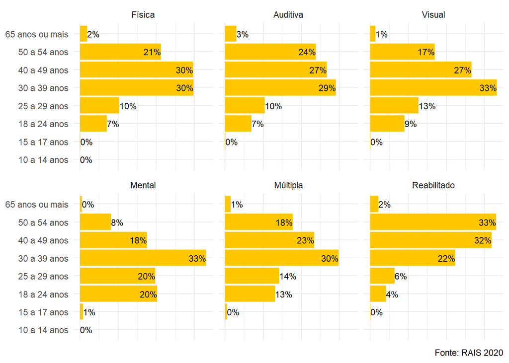

# 3 Mercado de trabalho - RAIS 2020

## 3.1 Desligados

Em 2020, **29,86% das pessoas do mercado formal foram desligadas**. Uma proporção ligeiramente maior do que as pessoas que foram desligadas com deficiência no mesmo ano.

**Desligados**

| Desligamento | Qtd Absoluta | Porcentagem |
| --- | --- | --- |
| Não | 495.479 | 79.43% |
| Sim | 128.348 | 20.57% |

*Fonte: RAIS 2020*

## 3.2 Tipo de vínculo empregatício

Os dados com relação ao tipo de vínculo empregatício confirmam a dificuldade maior que é para a pessoa com deficiência ingressar no serviço público. Enquanto no total da população, 18,92% possuem vínculo estatutário, ou seja, são servidores públicos ou empregados em empresas públicas, entre as pessoas com deficiência, esse percentual é de apenas 6,17%.

**Vínculo empregatício**

| Tipo de Vínculo | Qtd Absoluta | Porcentagem |
| --- | --- | --- |
| Celetista | 562.213 | 90.12% |
| Estatutário | 38.483 | 6.17% |
| Outros | 23.131 | 3.71% |

*Fonte: RAIS 2020*

## 3.3 Motivos do desligamento

A tabela abaixo mostra os **dez maiores motivos para o desligamento** entre as pessoas com deficiência. Os motivos de desligamento não diferem muito da base geral de dados.

**Motivo do Desligamento**

| Motivo | Porcentagem |
| --- | --- |
| Rescisão sem justa causa por iniciativa do empregador. | 46.96% |
| Rescisão sem justa causa por iniciativa do empregado ou exoneração a pedido | 23.11% |
| Transferência de empregado entre estabelecimentos da mesma empresa ou para outra empresa, sem ônus para a cedente | 14.45% |
| Término do contrato de trabalho. | 9.31% |
| Rescisão com justa causa por iniciativa do empregador ou servidor demitido | 2.28% |
| Desligamento por Acordo Empregado e Empregador | 1.21% |
| Falecimento. | 1.17% |
| Aposentadoria por tempo de serviço, sem rescisão contratual. | 0.46% |
| Rescisão com justa causa por iniciativa do empregado (rescisão indireta). | 0.31% |
| Transferência de empregado entre estabelecimentos da mesma empresa ou para outra empresa, com ônus para a cedente | 0.20% |

*Fonte: RAIS 2020*

## 3.4 Faixa de Tempo de Emprego (Meses)

Com relação à faixa de tempo no emprego, os dados sugerem que, quando se trata de pessoas reabilitadas, o percentual daqueles que permanecem no emprego por 120 meses ou mais é maior (45%) que o percentual das pessoas com deficiência em relação a essa mesma faixa de tempo.

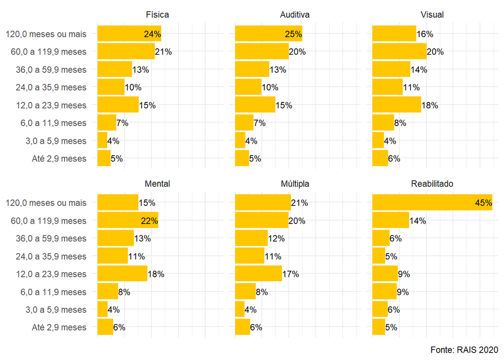

## 3.5 Faixa de Horas Contratuais Semanais

Ao observar as proporções da tabela abaixo, percebe-se a maioria dos empregados com deficiência trabalha entre 41 a 44 horas semanais. A base completa informa que 63,2% das pessoas com emprego formal trabalham na faixa de 41 a 44 horas semanais.

**Faixa de horas**

| Faixa de horas | Qtd Absoluta | Porcentagem |
| --- | --- | --- |
| Até 12 horas | 5.321 | 0.85% |
| 13 a 15 horas | 3.172 | 0.51% |
| 16 a 20 horas | 18.552 | 2.97% |
| 21 a 30 horas | 40.450 | 6.48% |
| 31 a 40 horas | 134.644 | 21.58% |
| 41 a 44 horas | 409.991 | 65.72% |

*Fonte: RAIS 2020*

## 3.6 Faixa de Remuneração Média em Salários Mínimos Correntes

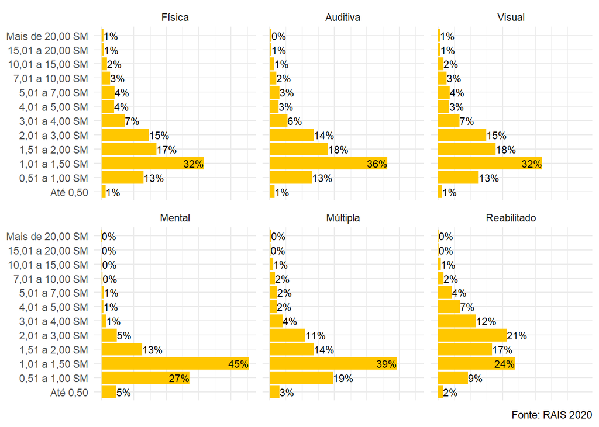

## 3.7 Ocupação

Com relação à ocupação, é possível perceber que quando se trata das demais deficiências, a primeira ocupação é a de auxiliar de escritório, enquanto, quando se trata das pessoas com deficiência intelectual predomina a função de embalador. Esse dado sugere que pode haver uma percepção equivocada por parte de empregadores com relação à deficiência intelectual, associando-a à incapacidade para o exercício de atividades intelectuais.

**Ocupações**

|  | Ocupação | Qtd Absoluta | Porcentagem |
| --- | --- | --- | --- |
| Física | Auxiliar de escritório | 25.060 | 9.08% |
|  | Assistente administrativo | 23.540 | 8.53% |
|  | Faxineiro | 11.209 | 4.06% |
|  | Alimentador de linha de produção | 9.176 | 3.33% |
|  | Repositor de mercadorias | 6.310 | 2.29% |
| Auditiva | Auxiliar de escritório | 7.848 | 7.07% |
|  | Alimentador de linha de produção | 7.483 | 6.74% |
|  | Faxineiro | 6.677 | 6.01% |
|  | Assistente administrativo | 6.178 | 5.56% |
|  | Repositor de mercadorias | 5.747 | 5.18% |
| Visual | Auxiliar de escritório | 7.919 | 7.56% |
|  | Assistente administrativo | 7.781 | 7.43% |
|  | Faxineiro | 5.053 | 4.83% |
|  | Alimentador de linha de produção | 4.337 | 4.14% |
|  | Repositor de mercadorias | 2.978 | 2.84% |
| Mental | Embalador, a mão | 6.851 | 12.02% |
|  | Repositor de mercadorias | 6.161 | 10.81% |
|  | Auxiliar de escritório | 4.573 | 8.02% |
|  | Alimentador de linha de produção | 3.724 | 6.53% |
|  | Faxineiro | 3.383 | 5.94% |
| Múltipla | Auxiliar de escritório | 902 | 8.36% |
|  | Faxineiro | 798 | 7.40% |
|  | Embalador, a mão | 740 | 6.86% |
|  | Repositor de mercadorias | 648 | 6.01% |
|  | Assistente administrativo | 599 | 5.55% |
| Reabilitado | Auxiliar de escritório | 5.141 | 7.98% |
|  | Assistente administrativo | 4.640 | 7.20% |
|  | Atendente comercial (agência postal) | 3.171 | 4.92% |
|  | Servente de obras | 2.655 | 4.12% |
|  | Alimentador de linha de produção | 1.656 | 2.57% |

*Fonte: RAIS 2020*

## 3.8 Tamanho do Estabelecimento

Esses gráficos mostram que os estabelecimentos que mais empregam pessoas com deficiência intelectual são aqueles com 100 a 249 funcionários, ou seja, pequenos estabelecimentos. Cabe uma investigação futura sobre o porque as empresas com 1.000 ou mais empregados são as maiores empregadoras de pessoas com deficiência física, auditiva, visual, múltipla e reabilitados, mas são a segunda quando se trata de pessoas com deficiência intelectual.

A Lei de Cotas (art. 93 da Lei nº 8.213/91), estabelece que empresas com cem ou mais empregados preencham uma parcela de seus cargos com pessoas com deficiência.

Segundo a lei:

- Empresas com **100 a 200 empregados**, no míninimo, **2%** precisam ser portador de deficiência
- Empresas com **201 a 500 empregados**, no míninimo, **3%** precisam ser portador de deficiência
- Empresas com **501 a 1.000 empregados**, no míninimo, **4%** precisam ser portador de deficiência
- Empresas com **mais de 1.001 empregados**, no míninimo, **5%** precisam ser portador de deficiência

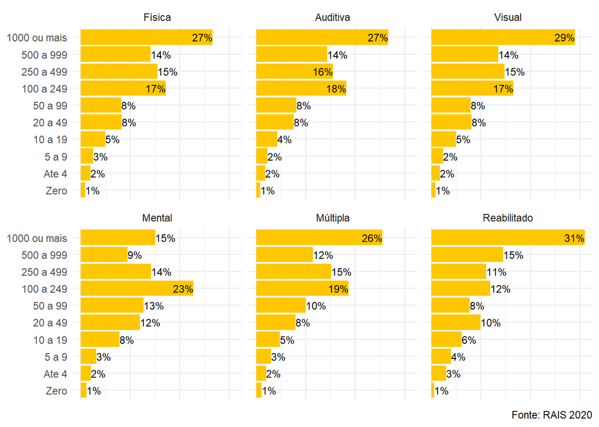

# 4 Estados RAIS 2020

## 4.1 Percentual Pessoas com deficiência no mercado de trabalho formal por Estado

O Estado de São Paulo, de longe, é o que mais emprega pessoas com deficiência. Este dado pode estar relacionado com o fato de que é o Estado mais populoso e é o principal polo econômico do país.

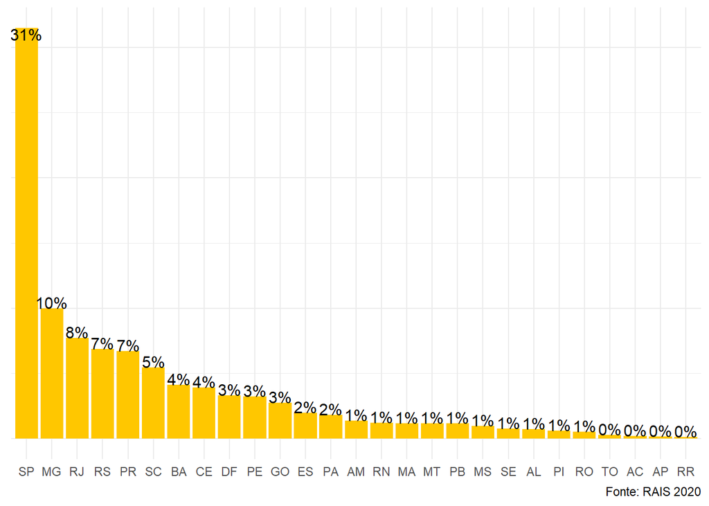

## 4.2 Renda média por Estado

O mapa abaixo mostra a média da renda anual média das pessoas com deficiência no mercado de trabalho.

Cores claras significam valores próximos à média enquanto cores escuras significam que os valores estão longe da média. Além disso, cores verdes são valores acima da média enquanto cores amarelas são valores abaixo da média. No ano de 2020 a média salárial nacional entre as pessoas com deficiência foi de **R$ 2604,54**.

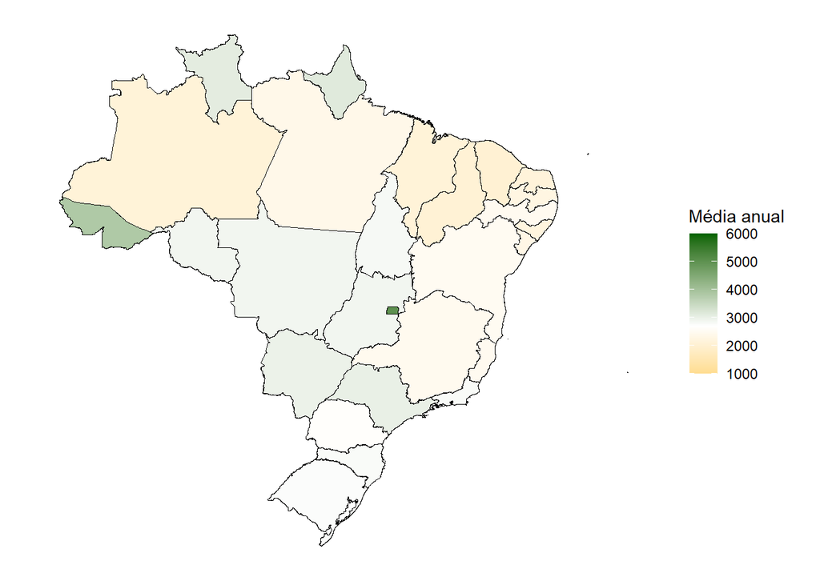